# Reproducible Research: Peer Assessment 1

Jessica Roland

11 May 2019

## Loading and preprocessing the data

Read in the data

```r
dataset <- read.csv("activity.csv")
```

Change date string to date format

```r
dataset$date <-(as.Date(dataset$date))
```

Get ggplot2 library

```r
library(ggplot2)
```

## What is mean total number of steps taken per day?

Get sum of steps per day

```r
dailySteps <- tapply(dataset$steps, dataset$date, FUN=sum, na.rm=TRUE)
```

Make a histogram of steps per day

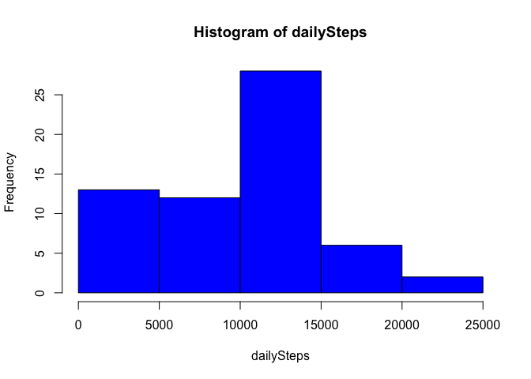

```r
hist(dailySteps,col="blue")
```

Calculate the mean steps per day

```r
dailyStepsMean <-mean(dailySteps, na.rm=TRUE)
dailyStepsMean
```

```
## [1] 9354.23
```

Calculate the median steps per day

```r
dailyStepsMedian <-median(dailySteps, na.rm=TRUE)
dailyStepsMedian
```

```
## [1] 10395
```

## What is the average daily activity pattern?

calculate mean of steps per interval

```r
average_steps <- aggregate(x=list(steps=dataset$steps), by=list(interval=dataset$interval),FUN=mean, na.rm=TRUE)
```

plot it

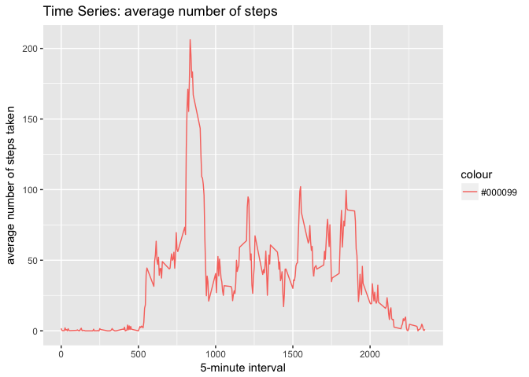

```r
ggplot(data=average_steps, aes(x=interval, y=steps, colour="#000099")) + geom_line() + ggtitle("Time Series: average number of steps") + xlab("5-minute interval") + ylab("average number of steps taken")
```

identify interval with the highest average max # of steps

```r
average_steps[which.max(average_steps$steps),]
```

```
##     interval    steps
## 104      835 206.1698
```

## Imputing missing values

count the number of NAs (missing data)

```r
sum(is.na(dataset$steps))
```

```
## [1] 2304
```

replace NA values with the mean of the steps

```r
dataset$steps[is.na(dataset$steps)]<-mean(dataset$steps,na.rm=TRUE)
```

Get sum of steps per day with the NA values replaced

```r
replacedNA_dailySteps <- tapply(dataset$steps, dataset$date, FUN=sum, na.rm=TRUE)
```

Make a histogram of steps per day with the NA values replaced

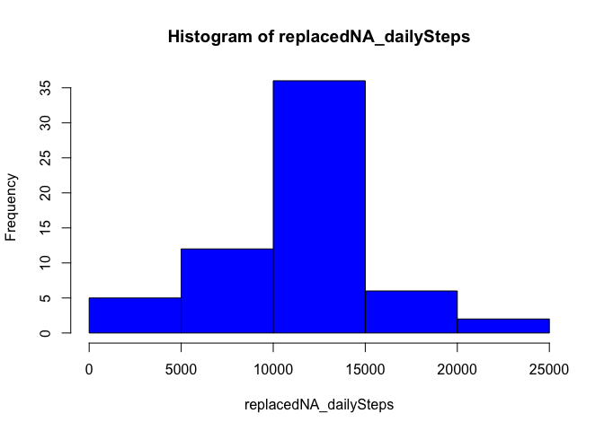

```r
hist(replacedNA_dailySteps,col="blue")
```

Calculate the new “replacedNA” mean steps per day

```r
replacedNA_dailyStepsMean <-mean(replacedNA_dailySteps, na.rm=TRUE)

replacedNA_dailyStepsMean
```

```
## [1] 10766.19
```

Calculate the new “replacedNA” median steps per day

```r
replacedNA_dailyStepsMedian <-median(replacedNA_dailySteps, na.rm=TRUE)

replacedNA_dailyStepsMedian
```

```
## [1] 10766.19
```

## Are there differences in activity patterns between weekdays and weekends?

change date format to weekdays

```r
dataset$days=weekdays(dataset$date)
```

change day names to weekend or weekday

```r
dataset$days_type<-ifelse(dataset$days=="Saturday"|dataset$days=="Sunday","weekend","weekday")
```

calculate mean steps taken per interval, using the weekday/weekend categorization

```r
average_steps_byDaysType<-aggregate(dataset$steps,by=list(dataset$interval,dataset$days_type),FUN=mean,na.rm=TRUE)
```

simplify the column names in preparation for plotting

```r
colnames(average_steps_byDaysType)<-c("interval","day_type","steps")
```

plot the graphs of weekend versus weekday steps by interval

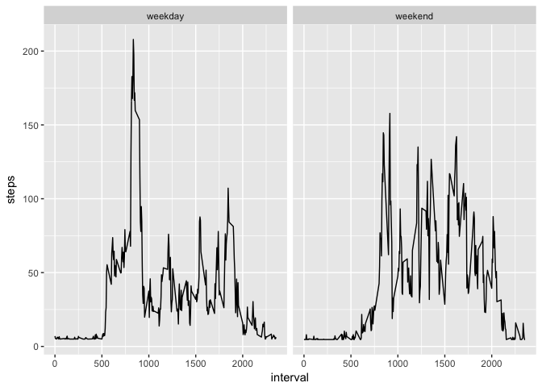

```r
ggplot(aes(x=interval,y=steps),data=average_steps_byDaysType)+geom_line()+facet_wrap(~average_steps_byDaysType$day_type)
```